# Worldbank Analysis

Robin Billinger, Leonie Mertes, Iman Saffari, Maximilian Frei

2025-01-21

## Agenda

1. Überblick und Terminologie
2. Datenanalyse

   2.1 Electricity and National Income  
   2.2 Education  
   2.3 HIV  
   2.4 Tobacco  
   2.5 Agriculture
3. Zusammenfassung und Diskussion

## Überblick

**Worldbank Datensatz**

- **Erhebungsart**: Logitudinal
- 25 Länder über 22 Jahre (2000 - 2021) untersucht

## 2.1 Electricity and National Income (1/2)

How does access to electricity correlate with adjusted net national income per capita across different countries?

## 2.1 Electricity and National Income (2/2)

Does this also depend on the country size or the inhabitants?

## 2.2 Education (1/2)

Do countries with **higher central government debt (% of GDP)** have a **lower % of labor force with basic education**?

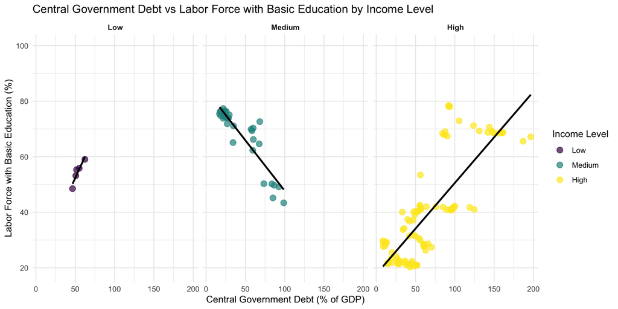

## 2.2 Education (2/2)

Are countries with higher percentage of labor force with basic education able to maintain **lower** pupil-teacher ratios, and what impact might this have on education quality?

## 2.3 HIV (1/2)

How does the HIV prevalence in the population aged 15-49 relate to the total alcohol consumption per capita?

## 2.3 HIV (2/2)

Do countries with higher percentage of labor force with basic education have lower HIV prevalence rates in the 15-49 population?

## 2.4 Tobacco (1/2)

How does GDP per capita relate to the prevalence of current tobacco use (% of adults)?

## 2.5 Agriculture (1/2)

Is there a relationship between the percentage of agricultural land and CO2 emissions per capita across countries?

## 2.5 Agriculture (2/2)

Does the size of the surface area of the country play a role?

## Zusammenfassung und Diskussion